# Analiza elektrowni

Łukasz Królik

04.12.2017

## Wstęp

W obecnych czasach toczą się starania o to, by środowisko uczynić czystszym oraz naturalniejszym. Energia odnawialna jest jednym z czołowych czynników tej walki. Elektrownie słoneczne (fotowoltaniczne) są jednymi z najmłodszych przedstawicieli tej gałęzi energetyki, jednocześnie rozwijając się niezwykle dynamicznie. W celu zoptymalizowania procesu produkcji prądu niezbędna jest wiedza na temat tego, ile energii zostanie wyprodukowane przez panele solarne, tak aby móc odpowiednio gospodarować energią w celu uniknięcia strat. Poniższy raport ma na celu znalezenie najważniejszych czynników wpływających na ilość wyprodukowanej energii a także przetestować popularne algorytmy próbujące dokonać predykcji tejże energii.

## Kod przetwarzający brakujące dane.

Zbiór nie zawiera wartości pustych (NA), co można sprawdzić za pomocą polecenia tabAll[rowSums(is.na(tabAll)) > 0,]. Niestety w toku przeszukiwania zbioru danych, udało się znaleźć dane, które jednoznacznie wskazywały na to, że nie wszystkie dane są rzetelne.

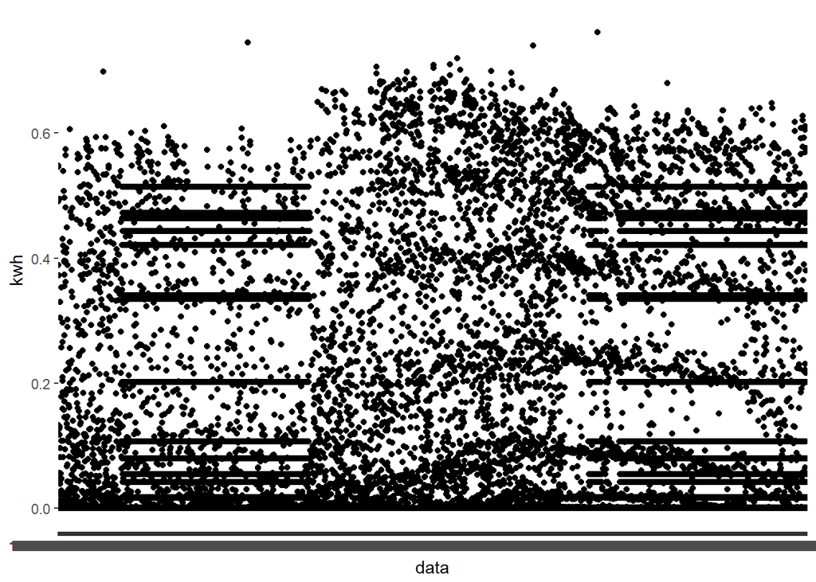

|  | id | idsito | idmodel | idbrand | lat | lon |
| --- | --- | --- | --- | --- | --- | --- |
| 184838 | 79150 | 0.1 | 0.167 | 0.167 | 0.434 | 0.63 |
| 184839 | 79167 | 0.1 | 0.167 | 0.167 | 0.434 | 0.63 |
| 184840 | 79184 | 0.1 | 0.167 | 0.167 | 0.434 | 0.63 |
| 184841 | 79201 | 0.1 | 0.167 | 0.167 | 0.434 | 0.63 |
| 184842 | 79218 | 0.1 | 0.167 | 0.167 | 0.434 | 0.63 |
| 184843 | 79235 | 0.1 | 0.167 | 0.167 | 0.434 | 0.63 |
| 184844 | 79252 | 0.1 | 0.167 | 0.167 | 0.434 | 0.63 |
| 184845 | 79269 | 0.1 | 0.167 | 0.167 | 0.434 | 0.63 |
| 184846 | 79286 | 0.1 | 0.167 | 0.167 | 0.434 | 0.63 |
| 184847 | 79303 | 0.1 | 0.167 | 0.167 | 0.434 | 0.63 |
| 184848 | 79320 | 0.1 | 0.167 | 0.167 | 0.434 | 0.63 |

Stan taki jest zdecydowanie niepoprawny, dlatego też zostały usunięte wszystkie dane, które w ciągu dnia miały inną liczbę obserwacji niż 19.

## Sekcję podsumowującą rozmiar zbioru i podstawowe statystyki.

| Statistic | N | Mean | St. Dev. | Min | Max |
| --- | --- | --- | --- | --- | --- |
| id | 235,790 | 152,702.900 | 77,627.610 | 1 | 276,488 |
| idsito | 235,790 | 0.215 | 0.133 | 0.000 | 0.425 |
| idmodel | 235,790 | 0.243 | 0.172 | 0.000 | 0.750 |
| idbrand | 235,790 | 0.152 | 0.119 | 0.000 | 0.417 |
| lat | 235,790 | 0.450 | 0.038 | 0.415 | 0.553 |
| lon | 235,790 | 0.571 | 0.152 | 0.154 | 0.691 |
| ageinmonths | 235,790 | 0.314 | 0.378 | 0.000 | 1.000 |
| anno | 235,790 | 2,012.500 | 0.500 | 2,012 | 2,013 |
| day | 235,790 | 0.481 | 0.276 | 0.000 | 1.000 |
| ora | 235,790 | 0.500 | 0.304 | 0.000 | 1.000 |
| temperatura_ambiente | 235,790 | 0.373 | 0.172 | 0.045 | 0.818 |
| irradiamento | 235,790 | 0.109 | 0.134 | 0.000 | 0.710 |
| pressure | 235,790 | 0.650 | 0.258 | 0.000 | 0.769 |
| windspeed | 235,790 | 0.076 | 0.050 | 0.000 | 0.696 |
| humidity | 235,790 | 0.684 | 0.182 | 0.160 | 1.000 |
| icon | 235,790 | 0.462 | 0.308 | 0.000 | 0.750 |
| dewpoint | 235,790 | 0.606 | 0.096 | 0.139 | 0.865 |
| windbearing | 235,790 | 0.451 | 0.230 | 0.000 | 0.769 |
| cloudcover | 235,790 | 0.359 | 0.260 | 0.000 | 1.000 |
| tempi | 235,790 | 0.122 | 0.063 | 0.009 | 0.983 |
| irri | 235,790 | 0.222 | 0.012 | 0.108 | 1.000 |
| pressurei | 235,790 | 0.0002 | 0.004 | 0.000 | 1.000 |
| windspeedi | 235,790 | 0.039 | 0.005 | 0.000 | 1.000 |
| humidityi | 235,790 | 0.064 | 0.042 | 0.034 | 0.579 |
| dewpointi | 235,790 | 0.119 | 0.013 | 0.063 | 0.415 |
| windbearingi | 235,790 | 0.345 | 0.034 | 0.000 | 1.000 |
| cloudcoveri | 235,790 | 0.206 | 0.030 | 0.000 | 1.000 |
| dist | 235,790 | 0.469 | 0.297 | 0.000 | 1.000 |
| altitude | 235,790 | 0.546 | 0.181 | 0.111 | 0.884 |
| azimuth | 235,790 | 0.455 | 0.197 | 0.128 | 0.818 |
| altitudei | 235,790 | 0.206 | 0.149 | 0.000 | 0.982 |
| azimuthi | 235,790 | 0.365 | 0.182 | 0.000 | 1.000 |
| pcnm1 | 235,790 | 0.422 | 0.204 | 0.000 | 1.000 |
| pcnm2 | 235,790 | 0.354 | 0.214 | 0.000 | 0.972 |
| pcnm3 | 235,790 | 0.604 | 0.217 | 0.000 | 1.000 |
| pcnm4 | 235,790 | 0.519 | 0.256 | 0.000 | 1.000 |
| pcnm5 | 235,790 | 0.416 | 0.250 | 0.000 | 1.000 |
| pcnm6 | 235,790 | 0.494 | 0.239 | 0.000 | 1.000 |
| pcnm7 | 235,790 | 0.114 | 0.225 | 0.000 | 1.000 |
| pcnm8 | 235,790 | 0.403 | 0.264 | 0.000 | 1.000 |
| pcnm9 | 235,790 | 0.537 | 0.262 | 0.000 | 1.000 |
| pcnm10 | 235,790 | 0.628 | 0.212 | 0.000 | 1.000 |
| pcnm11 | 235,790 | 0.324 | 0.207 | 0.000 | 1.000 |
| pcnm12 | 235,790 | 0.757 | 0.229 | 0.000 | 1.000 |
| pcnm13 | 235,790 | 0.650 | 0.200 | 0.137 | 1.000 |
| pcnm14 | 235,790 | 0.489 | 0.184 | 0.000 | 1.000 |
| pcnm15 | 235,790 | 0.571 | 0.205 | 0.000 | 1.000 |
| irr_pvgis_mod | 235,790 | 0.177 | 0.221 | 0.000 | 1.000 |
| irri_pvgis_mod | 235,790 | 0.197 | 0.053 | -0.025 | 1.006 |
| kwh | 235,790 | 0.169 | 0.211 | 0.000 | 1.000 |

## Szczegółową analizę wartości atrybutów (np. poprzez prezentację rozkładów wartości).

Otrzymana ramka danych składa się z 235790 obserwacji i 51 atrybutów. Można je podzielić na następujące kategorie:

#### Atrybuty opisujące czujniki oraz obserwacje:

Każdy czujnik ma swój identyfikator oraz informacje na temat marki i modelu czujnika a także wieku czujnika (ageinmonths). Informacje na temat obiektów są znormalizowane metodą min-max. Maksymalny identyfikator nie jest jedna równy jeden, co może być spowodowane tym, że pozostałe czujniki trafiły do zbioru testowego. Dodatkowo każda oberwacja zawiera identyfikator, przestawiony w postaci liczby nieznormalizowanej.

#### Atrybuty opisujące położenie geograficzne

Opis przestrzeni w jakiej znajdują się czujniki zawiera informacje na temat szerokości (lat) i długości (lon) geograficznej, a także informacje o położeniu słońca, wyrażonego w postaci układ współrzędnych horyzontalnych - gdzie informacje zawarte są w postaci azymutu (azimuth) i wysokości (altitude).

#### Atrybuty opisujące warunki atmosferyczne

Do skutecznej predykcji wyprodukowanego prądu na podstawie warunków atmosferycznych zawarto w zbiorze informacje na temat : temperatury (temperatura_ambiente), natężenia światła (irr_pvgis_mod oraz irradiamento), ciśnienia (pressure), wilgotności powietrza (humidity), dewpoint(temperatura punktu rosy), kierunku wiatru(windbearing), zachmurzenia(cloudcover).

#### Atrybuty związane z zagadnieniami Autokorelacji Przestrzennej

Obecność w zbiorze danych licznych kolumn o nazwie PCNM(pcnm1..pcnm15) świadczyć może o tym, że nad zbiorem danych dokonywano prac, na podstawie których usiłowano badać zależności przestrzenne między czujnikami. Wyrazem tego było obliczenie wartości PCNM (Principal coordinates of neighbour matrix) - który jest pomocny przy obliczaniu tego, czy dane mogły ulec efektom korelacji przestrzennej. Wykorzystując zmienne pcnm podjęto próby obliczenia wartości zmiennych atmosferycznych, które są pozbawione anomalii wynikających z efektów autokorelacji przestrzennej. Zmienne te charakteryzują się tym, że mają na końcu podaną literkę ‘i’ (tempi,irri,pressurei,windspeedi,humidityi,dewpointi,windbearingi,cloudcoveri,irri_pvgis_mod,altitudei,azimuthi) - znaczenie tych zmiennych jest analogiczne jak w punkcie powyżej.

Poniższe wykresy przedstawiają zmiany wszystkich atrybutów w przeciągu jednego miesiąca dla jednego czujnika.

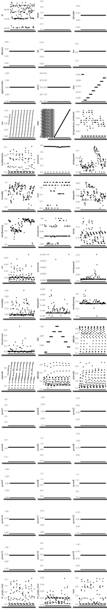

## Korelacje między zmiennymi

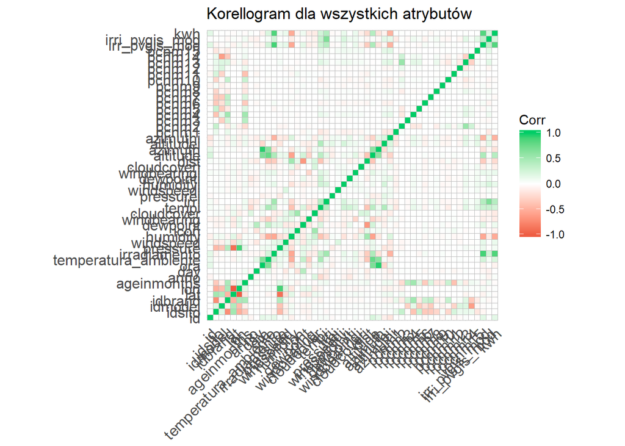

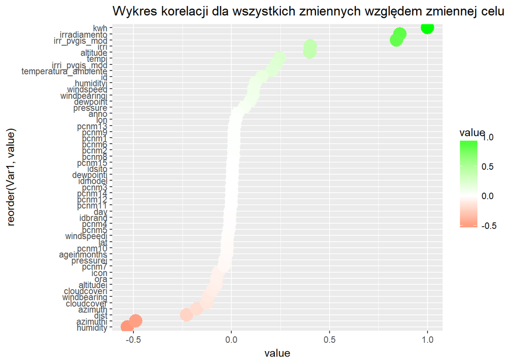

Wyniki nie odbiegają specjalnie od tego, czegobyśmy oczekiwali w codziennym życiu od elektrowni słonecznych. Są one ‘zasilane’ słońcem, stąd jest zrozumiałe, że natężenie słońca, wyrażone zmiennymi irradiamento oraz irr_pvgis_mod będzie kluczowe dla wzrostu produkcji prądu. Podobnie sprawa się ma w przypadku zmiennych odnoszących się do zachmurzenia. W tym przypadku korelacja jest ujemna, ponieważ przeszkadza ono w zwiększeniu natężeniu światła słonecznego.

## Wykres podsumowujący

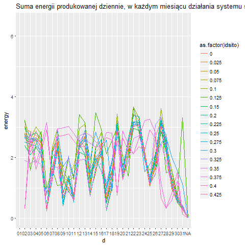

## Regresor

W celu znalezienia przewidywanej wartości zmiennej celu, należało zapoznać się z wybranymi modelami regresji i zastosować je na danych treningowych. Do tego celu skorzystałem z dwóch metod:

- Linear Regression (lm)
- Linear Regression with Forward Selection (leapForward)

W związku z brakiem dostatecznej ilości pamięci, zmuszony byłem do wybrania jedynie najmocniej skorelowanych kolumn spośród dostępnych w datasecie.

```
## $leapForward
## [1] 0.09977702
##
## $LM
## [1] 0.09967281
```

## Analiza ważności atrybutów algorytmu Linear Model

W celu znalezienia najlepszego modelu regresji należało skorzystać z funkcji dostarczonej wraz z biblioteką caret - czyli z varImp(). Dzięki temu poznaliśmy najistotniejsze atrybuty, mające kluczowe znaczenie przy ustaleniu wartości zmiennej celu. Są one następujące:

```
## lm variable importance
##
##               Overall
## irradiamento  100.000
## irr_pvgis_mod  65.204
## humidity       20.916
## azimuthi        5.112
## dist            0.000
```

Podobnie jak wskazywały wykresy korelacji, tak samo analiza ważności argumentów podpowiada nam, że najistotniejszym czynnikiem przy wytwarzaniu prądu w elektrowniach słonecznych jest natężenie światła. Jak się okazało w tym przypadku podstawowy model regresji liniowej spisał się lepiej niż jego modyfikacja.